# The Impact of Social Capital Strength on Job Search Confidence

DACSS 602 (Fall 2024)

Author

Astrid van Haren, Pengyang Li and Niranjan Prakash

# Introduction

This experiment explores the relationship between the strength of social capital and perceived confidence during a job search. Social capital is the network of relationships and connections individuals can leverage for career advancement, while job search confidence reflects an individual’s self-assurance when seeking employment. Understanding this relationship is crucial for identifying how different social networks can impact job search outcomes.

# Methodology

## (1) Experiment design

This experiment investigates the relationship between the intensity of social capital and job-seeking confidence. The design follows a two-way factorial structure, where two independent variables (IVs) are manipulated: social capital by rank and social capital by closeness of association. Participants were asked to report their confidence during a job application process based on their social networks, and the effects of these two IVs on three outcome variables (job-seeking confidence) were analyzed.

## (2) Treatments

The treatments in this experiment are based on two factors: social capital rank and social capital closeness. Social capital rank refers to the perceived strength or status of an individual’s social network, while social capital closeness refers to the emotional closeness and intimacy within these relationships. Participants were categorized into different levels of these factors to assess how each factor influences job-seeking confidence.

## (3) Outcome variable(s)

The primary outcome variables (DVs) are three dimensions of job-seeking confidence:

• DV1: Confidence in strength of recommendation letter.

• DV2: Confidence in the effectiveness of job-seeking strategies.

• DV3: Confidence that the recommendation letter is an accurate representation of their ability.

These outcome variables are measured using Likert-scale survey responses, ranging from low to high confidence.

## (4) Sample size

The sample consists of 220 valid responses from the fa24_omnibus1 data-set. The data cleaning process excluded participants who failed to meet the criteria for inclusion, such as those with low captcha scores or who had not consented to participate. This resulted in a final sample size of 220.

## (5) Data cleaning procedures

The data cleaning process included several steps to ensure the quality and validity of the data:

• Exclusion of Pilot Data: 20 pilot responses were removed from the data-set to focus on the final valid responses.

• Removal of Invalid Participants: Participants with a captcha score below 0.6 or those who did not provide consent were excluded from the analysis.

• Re-coding of Survey Responses: The categorical responses for the outcome variables were re coded into numerical values to facilitate statistical analysis. For example, confidence levels were converted to a 1-7 scale, with 1 representing the lowest level of confidence and 7 representing the highest.

• Handling Missing Data: Any missing or incomplete responses were omitted from the data-set to ensure the accuracy of the analysis.

# Analysis

Statistical Test Selection: The statistical test used in this study is Factorial ANOVA. This test was chosen because the design includes two independent variables (IVs)—social capital rank and social capital closeness—each with multiple levels, and three dependent variables (DVs) representing dimensions of job search confidence (DV1, DV2, DV3). Factorial ANOVA allows us to examine both the main effects of each IV and the interaction effects between the two IVs on the DVs. This approach is appropriate for analyzing the influence of multiple factors in a single experiment.

## (1) Import Libraries and Data

```r
library(tidyr)
library(dplyr)
library(readxl)
library(haven)
library(stringr)
library(ggplot2)
library(lsr)

exp_data <- read.csv("fa24_g3.csv")

head(exp_data)
```

|  | X | id | IV_rank | IV_closeness | age | gender | hhi | ethnicity | hispanic | education | political_party | region | zip | g5sd1 | dv1 | dv2 | dv3 |
| --- | --- | --- | --- | --- | --- | --- | --- | --- | --- | --- | --- | --- | --- | --- | --- | --- | --- |
| 1 | 1 | 1 | named | close | 38 | 1 | 1 | 1 | 1 | -3105 | 4 | 3 | 35094 | Female | Moderately confident | Neutral | Moderately |
| 2 | 2 | 2 | asso | close | 67 | 2 | 1 | 2 | 1 | 1 | 1 | 3 | 77063 | Female | Slightly confident | Very confident | Extremely confident |
| 3 | 3 | 3 | named | close | 29 | 1 | 4 | 15 | 2 | 5 | 5 | 4 | 85023 | Male | Slightly confident | Somewhat agree | Somewhat |
| 4 | 4 | 4 | named | limited | 45 | 2 | 4 | 1 | 14 | 2 | 1 | 4 | 85621 | Female | Somewhat confident | Neutral | Moderately |
| 5 | 5 | 5 | named | limited | 56 | 2 | 1 | 2 | 1 | 6 | 3 | 2 | 45211 | Female | Not confident at all | Strongly disagree | Not at all |
| 6 | 6 | 6 | named | limited | 31 | 1 | 17 | 1 | 1 | 6 | 1 | 3 | 77904 | Male | Fully confident | Strongly agree | Completely |

```r
str(exp_data)
```

```
'data.frame':   220 obs. of  17 variables:
 $ X              : int  1 2 3 4 5 6 7 8 9 10 ...
 $ id             : int  1 2 3 4 5 6 7 8 9 10 ...
 $ IV_rank        : chr  "named" "asso" "named" "named" ...
 $ IV_closeness   : chr  "close" "close" "close" "limited" ...
 $ age            : int  38 67 29 45 56 31 42 35 40 79 ...
 $ gender         : int  1 2 1 2 2 1 2 2 2 1 ...
 $ hhi            : int  1 1 4 4 1 17 11 5 1 20 ...
 $ ethnicity      : int  1 2 15 1 2 1 10 2 2 1 ...
 $ hispanic       : int  1 1 2 14 1 1 1 1 10 1 ...
 $ education      : int  -3105 1 5 2 6 6 5 2 7 7 ...
 $ political_party: int  4 1 5 1 3 1 2 1 1 2 ...
 $ region         : int  3 3 4 4 2 3 2 3 1 3 ...
 $ zip            : int  35094 77063 85023 85621 45211 77904 57252 32608 11238 33547 ...
 $ g5sd1          : chr  "Female" "Female" "Male" "Female" ...
 $ dv1            : chr  "Moderately confident" "Slightly confident" "Slightly confident" "Somewhat confident" ...
 $ dv2            : chr  "Neutral" "Very confident" "Somewhat agree" "Neutral" ...
 $ dv3            : chr  "Moderately" "Extremely confident" "Somewhat" "Moderately" ...
```

```r
summary(exp_data)
```

```
       X                id           IV_rank          IV_closeness
 Min.   :  1.00   Min.   :  1.00   Length:220         Length:220
 1st Qu.: 55.75   1st Qu.: 55.75   Class :character   Class :character
 Median :110.50   Median :110.50   Mode  :character   Mode  :character
 Mean   :110.50   Mean   :110.50
 3rd Qu.:165.25   3rd Qu.:165.25
 Max.   :220.00   Max.   :220.00
      age            gender           hhi           ethnicity
 Min.   :18.00   Min.   :1.000   Min.   : 1.000   Min.   : 1.000
 1st Qu.:36.00   1st Qu.:1.000   1st Qu.: 3.000   1st Qu.: 1.000
 Median :50.00   Median :2.000   Median : 7.000   Median : 1.000
 Mean   :49.53   Mean   :1.591   Mean   : 8.995   Mean   : 2.023
 3rd Qu.:63.00   3rd Qu.:2.000   3rd Qu.:15.000   3rd Qu.: 2.000
 Max.   :80.00   Max.   :2.000   Max.   :24.000   Max.   :16.000
    hispanic        education        political_party     region
 Min.   : 1.000   Min.   :-3105.00   Min.   :1.000   Min.   :1.000
 1st Qu.: 1.000   1st Qu.:    2.00   1st Qu.:1.000   1st Qu.:2.000
 Median : 1.000   Median :    4.00   Median :2.000   Median :3.000
 Mean   : 1.795   Mean   :  -23.96   Mean   :2.464   Mean   :2.405
 3rd Qu.: 1.000   3rd Qu.:    6.00   3rd Qu.:3.000   3rd Qu.:3.000
 Max.   :16.000   Max.   :    8.00   Max.   :8.000   Max.   :4.000
      zip           g5sd1               dv1                dv2
 Min.   : 2108   Length:220         Length:220         Length:220
 1st Qu.:20785   Class :character   Class :character   Class :character
 Median :33736   Mode  :character   Mode  :character   Mode  :character
 Mean   :41478
 3rd Qu.:60620
 Max.   :99301
     dv3
 Length:220
 Class :character
 Mode  :character
```

## (2) Descriptive Statistics

```r
# Overall descriptive statistics
summary_entire_demo <- exp_data |>
  summarise(
    mean_age = mean(age, na.rm = TRUE),
    median_age = median(age, na.rm = TRUE),
    gender_dist = mean(gender, na.rm = TRUE),
    mean_hhi = mean(hhi, na.rm = TRUE),
    mean_ethnicity = mean(ethnicity, na.rm = TRUE),
    mean_hispanic = mean(hispanic, na.rm = TRUE),
    mean_education = mean(education, na.rm = TRUE)
  )
print(summary_entire_demo)
```

```
  mean_age median_age gender_dist mean_hhi mean_ethnicity mean_hispanic
1 49.52727         50    1.590909 8.995455       2.022727      1.795455
  mean_education
1      -23.96364
```

```r
# Group-based Descriptive Statistics

## Descriptive statistics by IV_rank
summary_IV_rank <- exp_data |>
  group_by(IV_rank) |>
  summarise(
    mean_age = mean(age, na.rm = TRUE),
    gender_distribution = mean(gender, na.rm = TRUE),
    mean_hhi = mean(hhi, na.rm = TRUE),
    mean_ethnicity = mean(ethnicity, na.rm = TRUE),
    mean_hispanic = mean(hispanic, na.rm = TRUE),
    mean_education = mean(education, na.rm = TRUE),
    count = n()
  )
print(summary_IV_rank)
```

```
# A tibble: 2 × 8
  IV_rank mean_age gender_distribution mean_hhi mean_ethnicity mean_hispanic
  <chr>      <dbl>               <dbl>    <dbl>          <dbl>         <dbl>
1 asso        50.2                1.64     9.28           2.08          1.71
2 named       48.9                1.54     8.71           1.96          1.88
# ℹ 2 more variables: mean_education <dbl>, count <int>
```

```r
## Descriptive statistics by IV_closeness
summary_IV_closeness <- exp_data |>
  group_by(IV_closeness) |>
  summarise(
    mean_age = mean(age, na.rm = TRUE),
    gender_distribution = mean(gender, na.rm = TRUE),
    mean_hhi = mean(hhi, na.rm = TRUE),
    mean_ethnicity = mean(ethnicity, na.rm = TRUE),
    mean_hispanic = mean(hispanic, na.rm = TRUE),
    mean_education = mean(education, na.rm = TRUE),
    count = n()
  )
print(summary_IV_closeness)
```

```
# A tibble: 2 × 8
  IV_closeness mean_age gender_distribution mean_hhi mean_ethnicity
  <chr>           <dbl>               <dbl>    <dbl>          <dbl>
1 close            50.1                1.57     8.50           2.07
2 limited          49.0                1.61     9.50           1.97
# ℹ 3 more variables: mean_hispanic <dbl>, mean_education <dbl>, count <int>
```

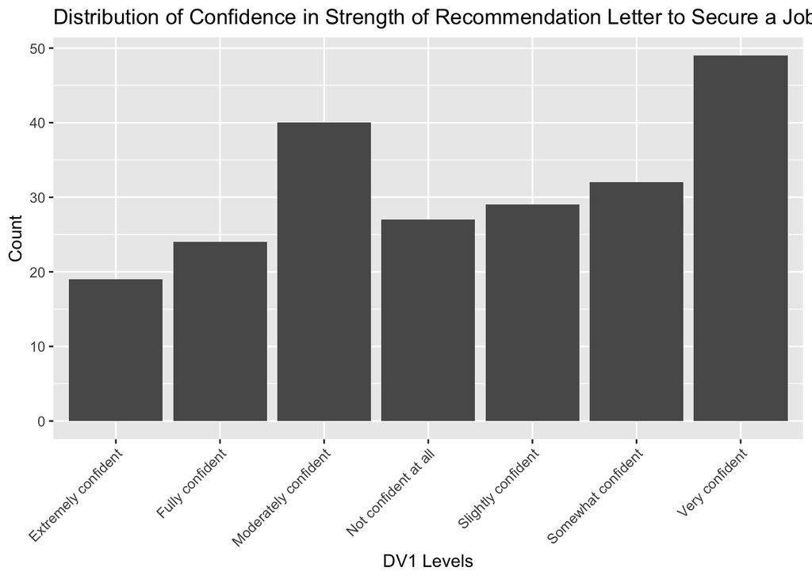

```r
## Plot distribution of dv1
ggplot(exp_data) +
  geom_bar(aes(x = as.factor(dv1))) +
  labs(
    title = "Distribution of Confidence in Strength of Recommendation Letter to Secure a Job",
    x = "DV1 Levels",
    y = "Count"
  ) +
  theme(axis.text.x = element_text(angle = 45, hjust = 1))
```

## (3) Recode Variables

```r
exp_data_coded <- exp_data |>
  mutate(dv1 = recode(dv1,
                     "Not confident at all" = 1,
                     "Slightly confident" = 2,
                     "Somewhat confident" = 3,
                     "Moderately confident" = 4,
                     "Very confident" = 5,
                     "Fully confident" = 7,
                     "Extremely confident" = 6),

         dv2 = recode(dv2,
                     "Strongly disagree" = 1,
                     "Disagree" = 2,
                     "Somewhat disagree" = 3,
                     "Neutral" = 4,
                     "Somewhat agree" = 5,
                     "Agree" = 6,
                     "Strongly agree" = 7,
                     "Not confident at all" = 1,
                     "Slightly confident" = 2,
                     "Somewhat confident" = 3,
                     "Moderately confident" = 4,
                     "Very confident" = 5,
                     "Fully confident" = 7,
                     "Extremely confident" = 6),

         dv3 = recode(dv3,
                     "Not at all" = 1,
                     "A little" = 2,
                     "Somewhat" = 3,
                     "Moderately" = 4,
                     "Very much" = 5,
                     "Extremely" = 6,
                     "Completely" = 7,
                     "Not confident at all" = 1,
                     "Slightly confident" = 2,
                     "Somewhat confident" = 3,
                     "Moderately confident" = 4,
                     "Very confident" = 5,
                     "Fully confident" = 7,
                     "Extremely confident" = 6))

# Check recoding results
summary(exp_data_coded$dv1)
```

```
   Min. 1st Qu.  Median    Mean 3rd Qu.    Max.
  1.000   2.000   4.000   3.945   5.000   7.000
```

```r
summary(exp_data_coded$dv2)
```

```
   Min. 1st Qu.  Median    Mean 3rd Qu.    Max.
  1.000   4.000   5.000   4.695   6.000   7.000
```

```r
summary(exp_data_coded$dv3)
```

```
   Min. 1st Qu.  Median    Mean 3rd Qu.    Max.
  1.000   3.000   4.000   4.309   6.000   7.000
```

## (4) Interaction Plots

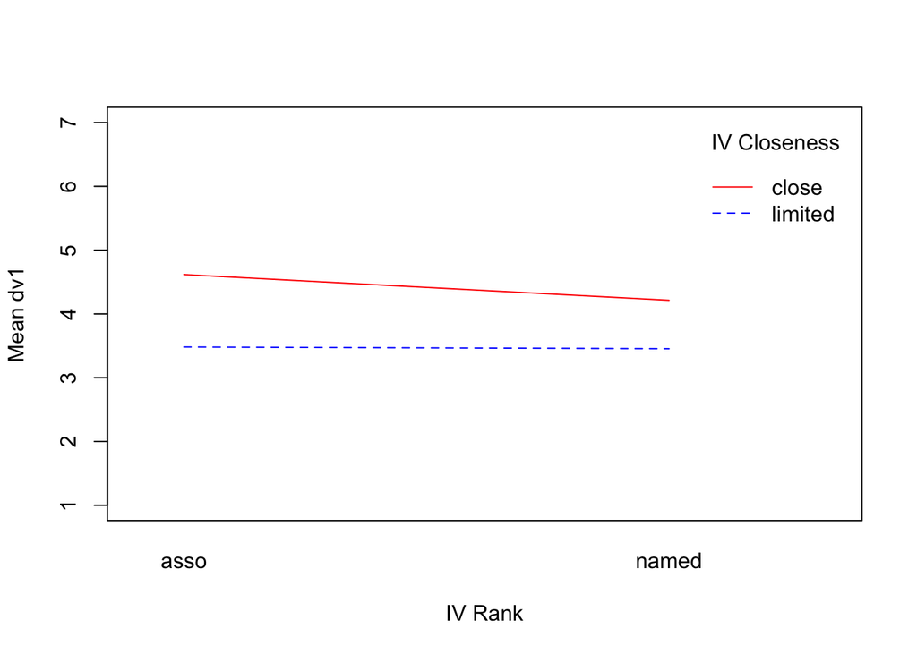

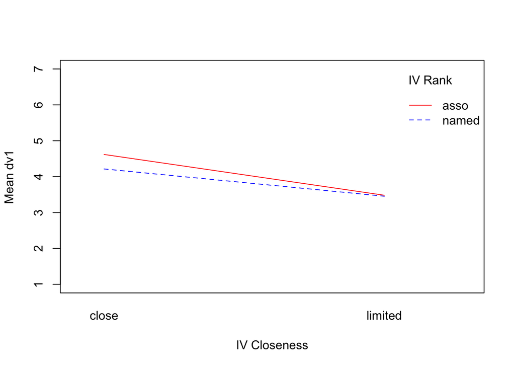

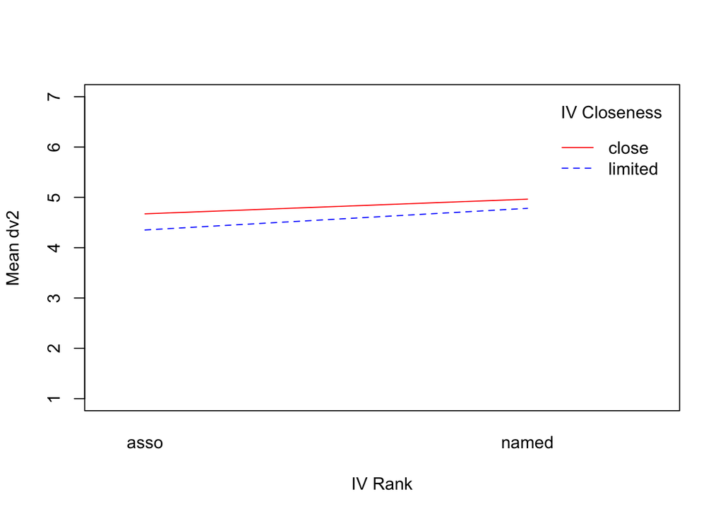

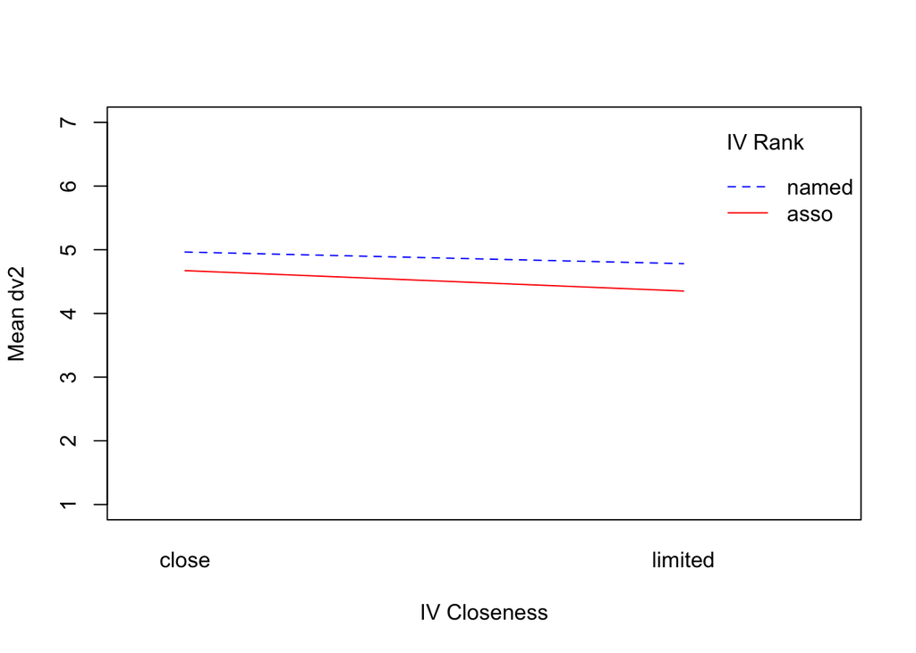

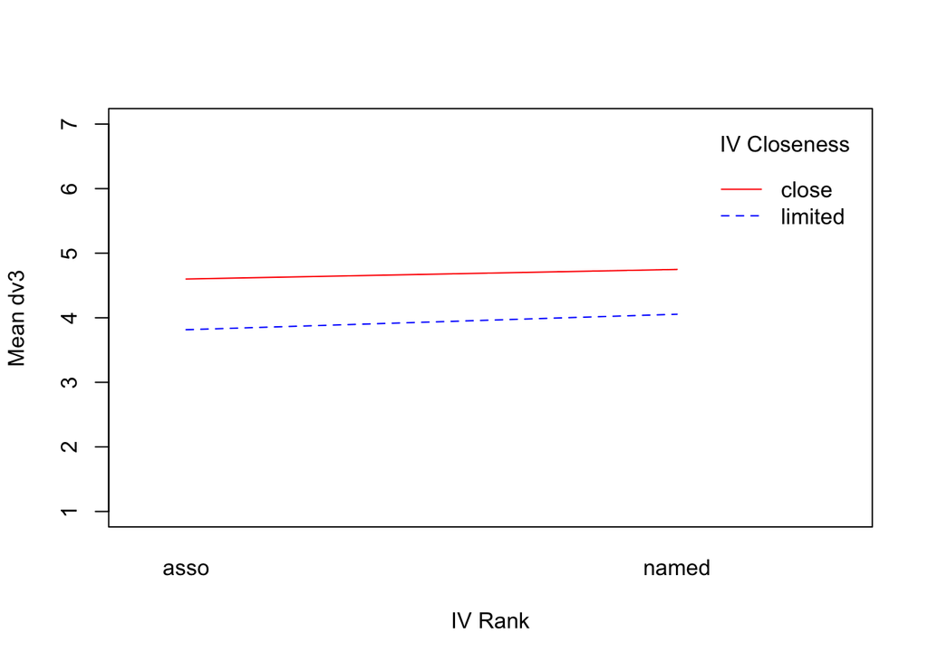

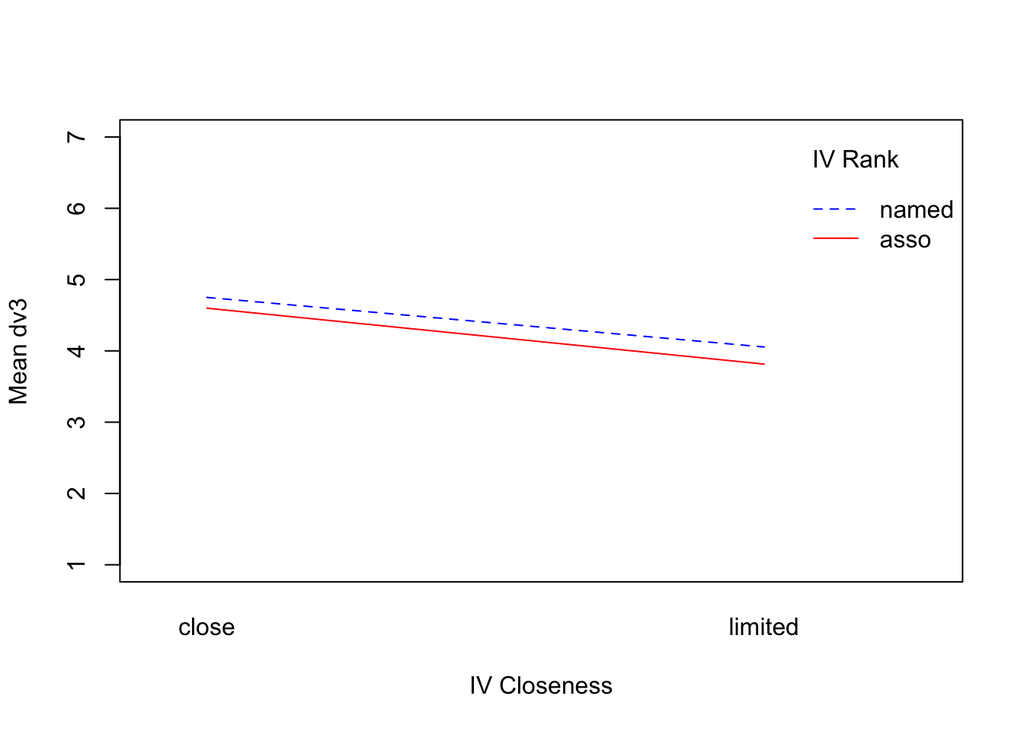

```r
# Generate interaction plots using a loop
for (dv in c("dv1", "dv2", "dv3")) {
  # IV_rank vs IV_closeness
  interaction.plot(x.factor = exp_data_coded$IV_rank,
                   trace.factor = exp_data_coded$IV_closeness,
                   response = exp_data_coded[[dv]],
                   xlab = "IV Rank",
                   ylab = paste("Mean", dv),
                   trace.label = "IV Closeness",
                   col = c("red", "blue"),
                   lty = 1:2,
                   ylim = c(1,7))

  # IV_closeness vs IV_rank
  interaction.plot(x.factor = exp_data_coded$IV_closeness,
                   trace.factor = exp_data_coded$IV_rank,
                   response = exp_data_coded[[dv]],
                   xlab = "IV Closeness",
                   ylab = paste("Mean", dv),
                   trace.label = "IV Rank",
                   col = c("red", "blue"),
                   lty = 1:2,
                   ylim = c(1,7))
}
```

## (5) Run Factorial ANOVA

```r
# Convert IVs to factor variables
exp_data_coded$IV_rank <- as.factor(exp_data_coded$IV_rank)
exp_data_coded$IV_closeness <- as.factor(exp_data_coded$IV_closeness)

# Run Factorial ANOVA for DV1
anova_dv1 <- aov(dv1 ~ IV_rank * IV_closeness, data = exp_data_coded)
summary(anova_dv1)
```

```
                      Df Sum Sq Mean Sq F value Pr(>F)
IV_rank                1    2.6    2.59   0.827 0.3641
IV_closeness           1   49.3   49.27  15.707 0.0001 ***
IV_rank:IV_closeness   1    2.0    1.95   0.623 0.4309
Residuals            216  677.5    3.14
---
Signif. codes:  0 '***' 0.001 '**' 0.01 '*' 0.05 '.' 0.1 ' ' 1
```

```r
etaSquared(anova_dv1, anova = TRUE)
```

```
                          eta.sq eta.sq.part         SS  df        MS
IV_rank              0.003545219 0.003812233   2.592780   1  2.592780
IV_closeness         0.067367663 0.067789240  49.269034   1 49.269034
IV_rank:IV_closeness 0.002671155 0.002875039   1.953537   1  1.953537
Residuals            0.926413408          NA 677.528235 216  3.136705
                              F            p
IV_rank               0.8265936 0.3642727186
IV_closeness         15.7072589 0.0001004856
IV_rank:IV_closeness  0.6227991 0.4308744070
Residuals                    NA           NA
```

```r
# Run Factorial ANOVA for DV2
anova_dv2 <- aov(dv2 ~ IV_rank * IV_closeness, data = exp_data_coded)
summary(anova_dv2)
```

```
                      Df Sum Sq Mean Sq F value Pr(>F)
IV_rank                1    7.1   7.132   2.577  0.110
IV_closeness           1    3.5   3.466   1.252  0.264
IV_rank:IV_closeness   1    0.3   0.263   0.095  0.758
Residuals            216  597.7   2.767
```

```r
etaSquared(anova_dv2, anova = TRUE)
```

```
                           eta.sq  eta.sq.part          SS  df        MS
IV_rank              0.0117199106 0.0117921536   7.1326843   1 7.1326843
IV_closeness         0.0056949736 0.0057650261   3.4659350   1 3.4659350
IV_rank:IV_closeness 0.0004327368 0.0004404059   0.2633617   1 0.2633617
Residuals            0.9821537293           NA 597.7342953 216 2.7672884
                              F         p
IV_rank              2.57749945 0.1098538
IV_closeness         1.25246614 0.2643250
IV_rank:IV_closeness 0.09516958 0.7580025
Residuals                    NA        NA
```

```r
# Run Factorial ANOVA for DV3
anova_dv3 <- aov(dv3 ~ IV_rank * IV_closeness, data = exp_data_coded)
summary(anova_dv3)
```

```
                      Df Sum Sq Mean Sq F value  Pr(>F)
IV_rank                1    2.1   2.078   0.747 0.38828
IV_closeness           1   30.1  30.108  10.827 0.00117 **
IV_rank:IV_closeness   1    0.1   0.111   0.040 0.84205
Residuals            216  600.7   2.781
---
Signif. codes:  0 '***' 0.001 '**' 0.01 '*' 0.05 '.' 0.1 ' ' 1
```

```r
etaSquared(anova_dv3, anova = TRUE)
```

```
                           eta.sq  eta.sq.part         SS  df        MS
IV_rank              0.0032853712 0.0034500732   2.079580   1  2.079580
IV_closeness         0.0475658890 0.0477309511  30.108343   1 30.108343
IV_rank:IV_closeness 0.0001748724 0.0001842409   0.110691   1  0.110691
Residuals            0.9489759335           NA 600.684512 216  2.780947
                               F           p
IV_rank               0.74779576 0.388134352
IV_closeness         10.82665184 0.001168354
IV_rank:IV_closeness  0.03980336 0.842053233
Residuals                     NA          NA
```

# Results

**1. Descriptive Statistics**

Descriptive statistics were calculated for each dependent variable (DV1, DV2, DV3) across the levels of the independent variables (IV Rank and IV Closeness). The means of the dependent variables for each combination of IV Rank and IV Closeness were calculated.

```r
# Calculating means for DV1, DV2, and DV3 across IV_rank and IV_closeness levels
dv1_means <- aggregate(dv1 ~ IV_rank + IV_closeness, data = exp_data_coded, FUN = mean)
dv2_means <- aggregate(dv2 ~ IV_rank + IV_closeness, data = exp_data_coded, FUN = mean)
dv3_means <- aggregate(dv3 ~ IV_rank + IV_closeness, data = exp_data_coded, FUN = mean)

# Displaying the mean values
dv1_means
```

| IV_rank | IV_closeness | dv1 |
| --- | --- | --- |
| asso | close | 4.618182 |
| named | close | 4.214286 |
| asso | limited | 3.481481 |
| named | limited | 3.454545 |

```r
dv2_means
```

| IV_rank | IV_closeness | dv2 |
| --- | --- | --- |
| asso | close | 4.672727 |
| named | close | 4.964286 |
| asso | limited | 4.351852 |
| named | limited | 4.781818 |

```r
dv3_means
```

| IV_rank | IV_closeness | dv3 |
| --- | --- | --- |
| asso | close | 4.600000 |
| named | close | 4.750000 |
| asso | limited | 3.814815 |
| named | limited | 4.054545 |

**2. Factorial ANOVA Results**

```r
# Factorial ANOVA for DV1
anova_dv1 <- aov(dv1 ~ IV_rank * IV_closeness, data = exp_data_coded)
summary(anova_dv1)
```

```
                      Df Sum Sq Mean Sq F value Pr(>F)
IV_rank                1    2.6    2.59   0.827 0.3641
IV_closeness           1   49.3   49.27  15.707 0.0001 ***
IV_rank:IV_closeness   1    2.0    1.95   0.623 0.4309
Residuals            216  677.5    3.14
---
Signif. codes:  0 '***' 0.001 '**' 0.01 '*' 0.05 '.' 0.1 ' ' 1
```

```r
# Calculating effect size
library(lsr)
etaSquared(anova_dv1, anova = TRUE)
```

```
                          eta.sq eta.sq.part         SS  df        MS
IV_rank              0.003545219 0.003812233   2.592780   1  2.592780
IV_closeness         0.067367663 0.067789240  49.269034   1 49.269034
IV_rank:IV_closeness 0.002671155 0.002875039   1.953537   1  1.953537
Residuals            0.926413408          NA 677.528235 216  3.136705
                              F            p
IV_rank               0.8265936 0.3642727186
IV_closeness         15.7072589 0.0001004856
IV_rank:IV_closeness  0.6227991 0.4308744070
Residuals                    NA           NA
```

```r
# Factorial ANOVA for DV2
anova_dv2 <- aov(dv2 ~ IV_rank * IV_closeness, data = exp_data_coded)
summary(anova_dv2)
```

```
                      Df Sum Sq Mean Sq F value Pr(>F)
IV_rank                1    7.1   7.132   2.577  0.110
IV_closeness           1    3.5   3.466   1.252  0.264
IV_rank:IV_closeness   1    0.3   0.263   0.095  0.758
Residuals            216  597.7   2.767
```

```r
etaSquared(anova_dv2, anova = TRUE)
```

```
                           eta.sq  eta.sq.part          SS  df        MS
IV_rank              0.0117199106 0.0117921536   7.1326843   1 7.1326843
IV_closeness         0.0056949736 0.0057650261   3.4659350   1 3.4659350
IV_rank:IV_closeness 0.0004327368 0.0004404059   0.2633617   1 0.2633617
Residuals            0.9821537293           NA 597.7342953 216 2.7672884
                              F         p
IV_rank              2.57749945 0.1098538
IV_closeness         1.25246614 0.2643250
IV_rank:IV_closeness 0.09516958 0.7580025
Residuals                    NA        NA
```

```r
# Factorial ANOVA for DV3
anova_dv3 <- aov(dv3 ~ IV_rank * IV_closeness, data = exp_data_coded)
summary(anova_dv3)
```

```
                      Df Sum Sq Mean Sq F value  Pr(>F)
IV_rank                1    2.1   2.078   0.747 0.38828
IV_closeness           1   30.1  30.108  10.827 0.00117 **
IV_rank:IV_closeness   1    0.1   0.111   0.040 0.84205
Residuals            216  600.7   2.781
---
Signif. codes:  0 '***' 0.001 '**' 0.01 '*' 0.05 '.' 0.1 ' ' 1
```

```r
etaSquared(anova_dv3, anova = TRUE)
```

```
                           eta.sq  eta.sq.part         SS  df        MS
IV_rank              0.0032853712 0.0034500732   2.079580   1  2.079580
IV_closeness         0.0475658890 0.0477309511  30.108343   1 30.108343
IV_rank:IV_closeness 0.0001748724 0.0001842409   0.110691   1  0.110691
Residuals            0.9489759335           NA 600.684512 216  2.780947
                               F           p
IV_rank               0.74779576 0.388134352
IV_closeness         10.82665184 0.001168354
IV_rank:IV_closeness  0.03980336 0.842053233
Residuals                     NA          NA
```

**3. Interaction Plots**

To visually examine the interaction effects between IV Rank and IV Closeness for each dependent variable, interaction plots were generated.

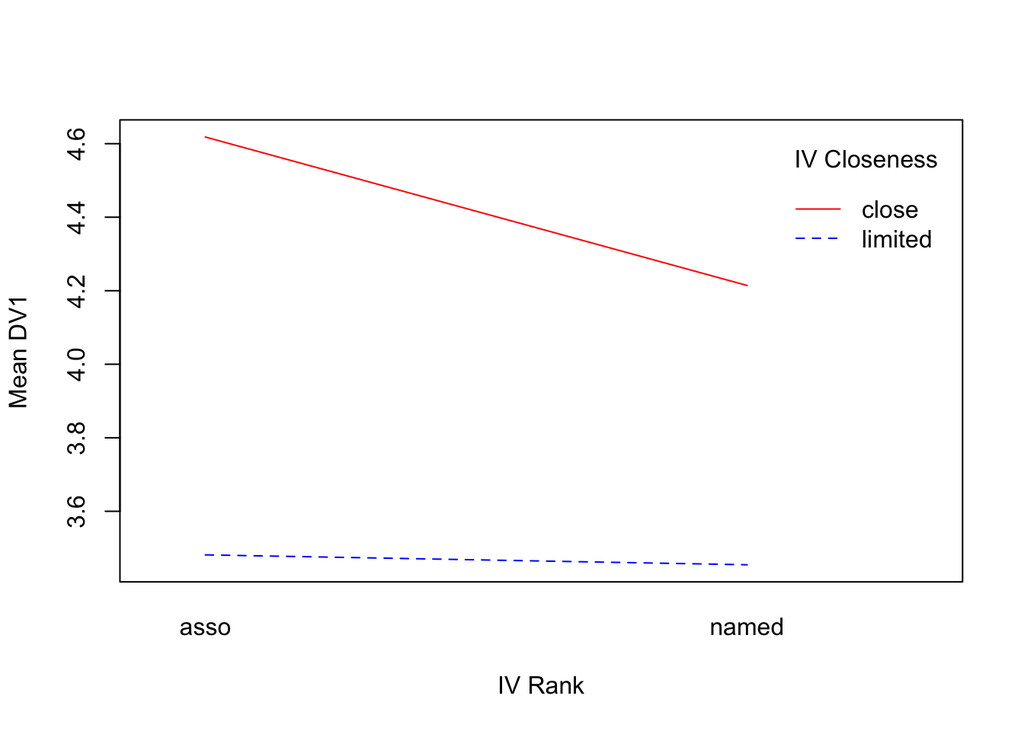

```r
# Interaction plot for DV1
interaction.plot(x.factor = exp_data_coded$IV_rank,
                 trace.factor = exp_data_coded$IV_closeness,
                 response = exp_data_coded$dv1,
                 xlab = "IV Rank",
                 ylab = "Mean DV1",
                 trace.label = "IV Closeness",
                 col = c("red", "blue"),
                 lty = 1:2)
```

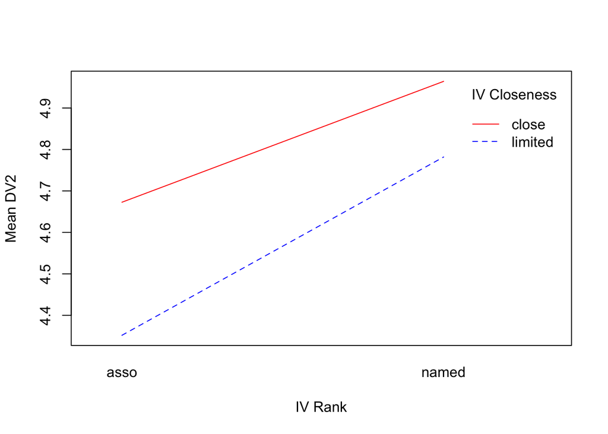

```r
# Interaction plot for DV2
interaction.plot(x.factor = exp_data_coded$IV_rank,
                 trace.factor = exp_data_coded$IV_closeness,
                 response = exp_data_coded$dv2,
                 xlab = "IV Rank",
                 ylab = "Mean DV2",
                 trace.label = "IV Closeness",
                 col = c("red", "blue"),
                 lty = 1:2)
```

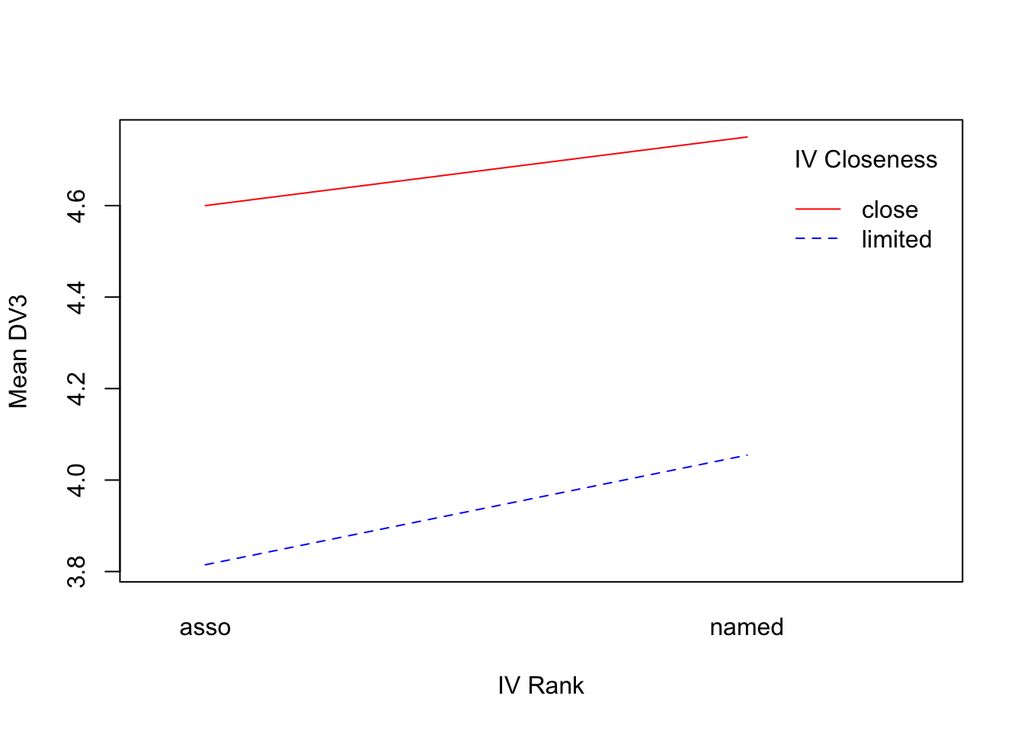

```r
# Interaction plot for DV3
interaction.plot(x.factor = exp_data_coded$IV_rank,
                 trace.factor = exp_data_coded$IV_closeness,
                 response = exp_data_coded$dv3,
                 xlab = "IV Rank",
                 ylab = "Mean DV3",
                 trace.label = "IV Closeness",
                 col = c("red", "blue"),
                 lty = 1:2)
```

# Findings

1. Factorial ANOVA Results

```r
# Results for DV1 ANOVA
summary(anova_dv1)
```

```
                      Df Sum Sq Mean Sq F value Pr(>F)
IV_rank                1    2.6    2.59   0.827 0.3641
IV_closeness           1   49.3   49.27  15.707 0.0001 ***
IV_rank:IV_closeness   1    2.0    1.95   0.623 0.4309
Residuals            216  677.5    3.14
---
Signif. codes:  0 '***' 0.001 '**' 0.01 '*' 0.05 '.' 0.1 ' ' 1
```

```r
# Results for DV2 ANOVA
summary(anova_dv2)
```

```
                      Df Sum Sq Mean Sq F value Pr(>F)
IV_rank                1    7.1   7.132   2.577  0.110
IV_closeness           1    3.5   3.466   1.252  0.264
IV_rank:IV_closeness   1    0.3   0.263   0.095  0.758
Residuals            216  597.7   2.767
```

**For DV3**: Finally, for DV3, we observed significant effects:

```r
# Results for DV3 ANOVA
summary(anova_dv3)
```

```
                      Df Sum Sq Mean Sq F value  Pr(>F)
IV_rank                1    2.1   2.078   0.747 0.38828
IV_closeness           1   30.1  30.108  10.827 0.00117 **
IV_rank:IV_closeness   1    0.1   0.111   0.040 0.84205
Residuals            216  600.7   2.781
---
Signif. codes:  0 '***' 0.001 '**' 0.01 '*' 0.05 '.' 0.1 ' ' 1
```

2. Effect Sizes

To further evaluate the strength of the effects, the eta-squared values for each ANOVA were calculated. These provide an indication of how much of the variance in the dependent variables is explained by the independent variables and their interaction.

```r
# Eta-squared for DV1
etaSquared(anova_dv1, anova = TRUE)
```

```
                          eta.sq eta.sq.part         SS  df        MS
IV_rank              0.003545219 0.003812233   2.592780   1  2.592780
IV_closeness         0.067367663 0.067789240  49.269034   1 49.269034
IV_rank:IV_closeness 0.002671155 0.002875039   1.953537   1  1.953537
Residuals            0.926413408          NA 677.528235 216  3.136705
                              F            p
IV_rank               0.8265936 0.3642727186
IV_closeness         15.7072589 0.0001004856
IV_rank:IV_closeness  0.6227991 0.4308744070
Residuals                    NA           NA
```

3. Visualizing the Interaction Effects

To better understand the interaction effects, we present interaction plots for each dependent variable. These plots illustrate the relationship between IV Rank and IV Closeness across the three dependent variables.

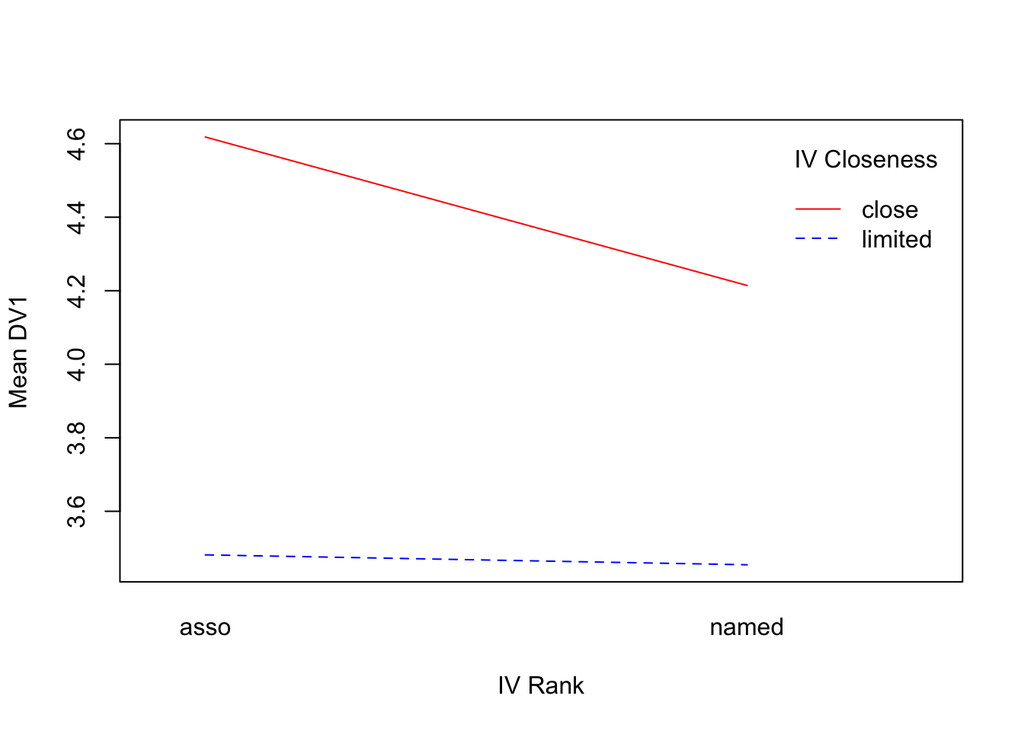

```r
# Interaction plot for DV1
interaction.plot(x.factor = exp_data_coded$IV_rank,
                 trace.factor = exp_data_coded$IV_closeness,
                 response = exp_data_coded$dv1,
                 xlab = "IV Rank",
                 ylab = "Mean DV1",
                 trace.label = "IV Closeness",
                 col = c("red", "blue"),
                 lty = 1:2)
```

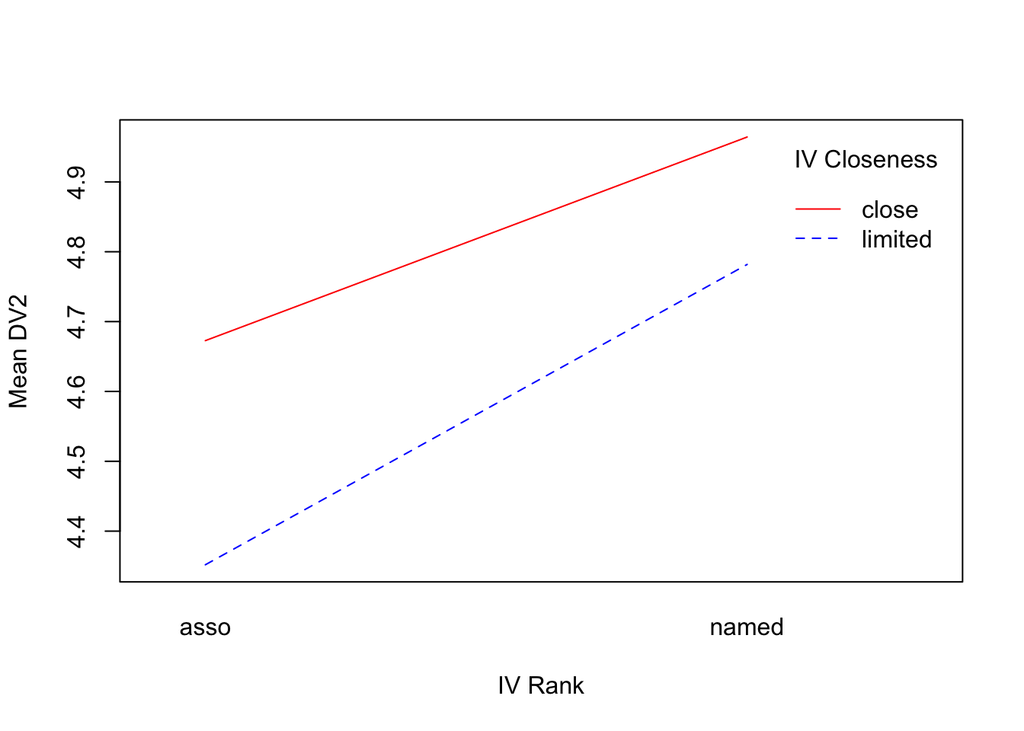

```r
# Interaction plot for DV2
interaction.plot(x.factor = exp_data_coded$IV_rank,
                 trace.factor = exp_data_coded$IV_closeness,
                 response = exp_data_coded$dv2,
                 xlab = "IV Rank",
                 ylab = "Mean DV2",
                 trace.label = "IV Closeness",
                 col = c("red", "blue"),
                 lty = 1:2)
```

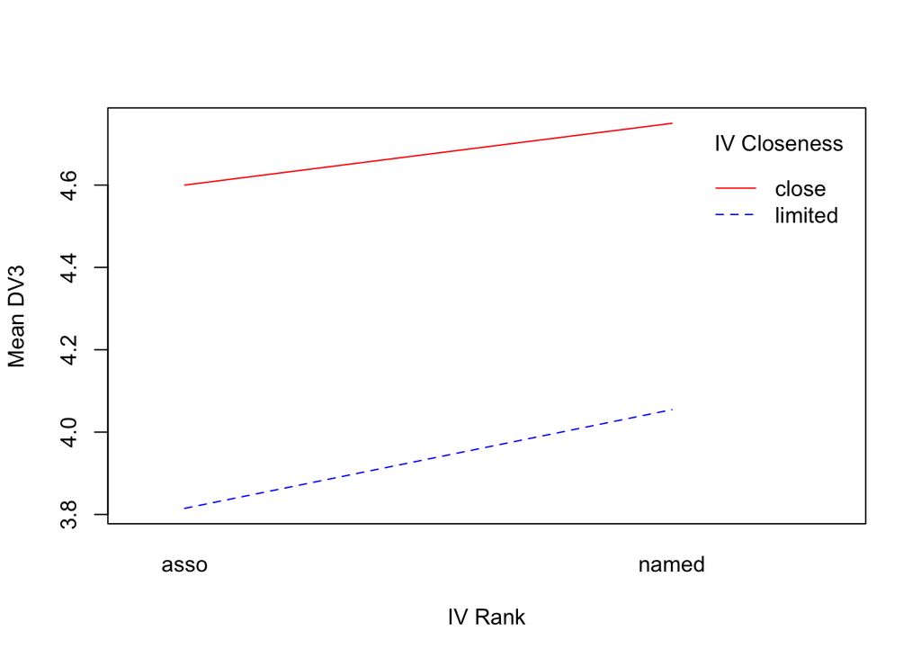

```r
# Interaction plot for DV3
interaction.plot(x.factor = exp_data_coded$IV_rank,
                 trace.factor = exp_data_coded$IV_closeness,
                 response = exp_data_coded$dv3,
                 xlab = "IV Rank",
                 ylab = "Mean DV3",
                 trace.label = "IV Closeness",
                 col = c("red", "blue"),
                 lty = 1:2)
```

# Discussion

**Implications of the Study**

The primary goal of this study was to explore how social capital, particularly the strength of relationships (such as support from friends, family, and peers), affects university students’ employment opportunities and their transition from college to career. The findings have important practical and theoretical implications:

**Theoretical Implications**: From a theoretical perspective, this study contributes to the application of social capital theory in the context of higher education and career development. The findings indicate that social capital extends beyond academic qualifications to include social relationships and support, which can significantly influence an individual’s career transition success. This provides empirical support for the social capital theory in the employment context.

**Possible Explanations if the Results Do Not Align with the Hypothesis**

If the results of the study do not align with the initial hypothesis, several possible explanations could account for this:

**1. Measurement and Definition Issue**s: While we hypothesized that strong social capital would play a key role in securing job opportunities, the measures of social capital used in the study might not fully capture its complexity. For instance, we might have underestimated the impact of informal networks (such as connections on social media) on employment outcomes. Additionally, the operationalization of social capital may have been limited, which could have led to inaccurate or incomplete measurements of its effects on employment.

**2. Cultural or Contextual Differences**: The study might not have fully accounted for cultural or contextual differences in the role of social capital. In some cultures or regions, students may rely more heavily on formal resources provided by universities (such as career services) rather than personal relationships. This cultural difference could lead to varying results, which may not align with the hypothesis.

**3. Sample Issues**: If the sample in the study is skewed toward certain groups (e.g., students from specific disciplines or universities in particular regions), the findings may not be generalizable to all students. A more diverse sample would help provide a more comprehensive understanding of the role of social capital in the job search process.

**4. Uncontrolled Variables**: There may have been other factors (such as career planning, family background, or job search skills) influencing the role of social capital in securing employment. If these factors were not controlled for in the analysis, they could have biased the results and led to conclusions that differ from the hypothesis.

**Suggestions for Future Research**

**1. Diverse Samples and Cultural Contexts**: Future research could involve a more diverse sample, including students from different regions and disciplines, to better understand the role of social capital in various contexts. This would help identify whether the effects of social capital vary across different groups of students.

**2. Refined Measurements**: To more accurately assess social capital, future studies could use more refined measurement tools, combining both quantitative and qualitative methods to capture the various dimensions of social capital (e.g., relationship strength, support types, network breadth).

**3. Longitudinal Research Designs**: Longitudinal studies would provide a deeper understanding of how social capital influences students’ career outcomes over time. Tracking students’ social capital and employment outcomes in the long term could reveal more detailed insights into how social capital contributes to career success.

**4. Exploring Other Potential Factors**: Future research could explore additional factors that might interact with social capital, such as job-search skills, academic achievements, and students’ self-confidence. This would help provide a more nuanced understanding of how social capital works alongside other individual characteristics.

**5. Intervention Studies**: Experimental or intervention studies could explore ways to effectively enhance students’ social capital, such as through structured networking programs or mentorship opportunities. These studies could offer practical strategies for universities and career services to support students in their job searches.